# Aide R - Laboratoire 02

Retrouver une commande après une première tentative

**NoteUtiliser cet exemple pour votre analyse**

Les exemples ci-dessous portent sur les ventes selon l’achalandage, comme au module 04. Ils servent à retrouver une commande après une tentative. Pour votre rapport sur les livraisons, remplacez les variables et les unités, puis utilisez les périodes du guide. Pour la séparation et la RMSE de validation, consultez aussi la démonstration du module 04.

## Utiliser cette aide

Suivez la mission et ouvrez la rubrique qui répond à votre difficulté. Adaptez les variables et les objets à votre analyse des livraisons.

Les blocs ci-dessous s’exécutent dans l’ordre pour reproduire cet exemple. Pour l’utiliser dans un projet indépendant, placez le CSV du module 4 dans `data/` et le `.qmd` à la racine.

Le dossier étudiant contient le script complet `aide-regression.R` et ce CSV pour refaire l’exemple sans réseau. Ici, les modèles sont ajustés sur toutes les lignes du CSV de saturation. Dans votre mission, ajustez-les uniquement sur les 72 livraisons d’apprentissage; gardez les 24 autres pour la validation.

## Ajouter un bloc dans le rapport

Dans RStudio, le bouton d’insertion de bloc permet d’ajouter du code R à une section. Le code reste dans les blocs; la justification et l’interprétation s’écrivent dans le texte. Donnez des noms distincts aux modèles pour conserver les deux ajustements.

## Importer et contrôler

**AstuceOuvrir l’exemple d’importation et de contrôle**

```r
library(tidyverse)

saturation <- read_csv("data/achalandage_saturation_quebec.csv",
                       show_col_types = FALSE) |>
  mutate(mois = as.Date(mois),
         achalandage_milliers = achalandage / 1000)

saturation |>
  summarise(observations = n(),
            succursales = n_distinct(succursale),
            debut = min(mois), fin = max(mois),
            visites_min = min(achalandage),
            visites_max = max(achalandage))
```

```
# A tibble: 1 × 6
  observations succursales debut      fin        visites_min visites_max
         <int>       <int> <date>     <date>           <dbl>       <dbl>
1           72           6 2025-01-01 2025-12-01        1151        4166
```

```r
sum(is.na(saturation))
```

```
[1] 0
```

```r
saturation |> count(succursale, mois) |> filter(n > 1)
```

```
# A tibble: 0 × 3
# ℹ 3 variables: succursale <chr>, mois <date>, n <int>
```

```r
# Un seul tableau complet pour tous les modèles de cet exemple.
stopifnot(all(complete.cases(saturation[c("ventes", "achalandage_milliers")])))
```

Vérifiez les colonnes effectivement utilisées. Si un contrôle échoue, examinez la cause avant de filtrer ou de modéliser.

## Construire la référence et une variante

**AstuceOuvrir l’exemple de modèles et de coefficients**

```r
modele_reference <- lm(ventes ~ achalandage_milliers, data = saturation)
modele_variante <- lm(
  ventes ~ achalandage_milliers + I(achalandage_milliers^2),
  data = saturation
)

coef(modele_reference)
```

```
         (Intercept) achalandage_milliers
           104578.87             25010.99
```

```r
summary(modele_reference)$r.squared
```

```
[1] 0.7702993
```

```r
# La variable est en milliers de visites : 100 visites représentent 0,1 unité.
unname(coef(modele_reference)["achalandage_milliers"] * 0.1)
```

```
[1] 2501.099
```

Pour retrouver la syntaxe d’un modèle logarithmique, dans le prolongement facultatif :

```r
stopifnot(all(saturation$achalandage_milliers > 0))
modele_variante <- lm(ventes ~ log(achalandage_milliers), data = saturation)
```

Dans le parcours essentiel, gardez la droite et le modèle quadratique prévus par le guide. Le logarithme reste facultatif. Les coefficients du modèle quadratique ne définissent pas une pente constante.

## Comparer des ajustements

**AstuceOuvrir l’exemple de tableau comparatif**

```r
comparaison <- tibble(
  modele = c("Droite", "Variante"),
  observations = c(nobs(modele_reference), nobs(modele_variante)),
  r2_ajuste = c(summary(modele_reference)$adj.r.squared,
                summary(modele_variante)$adj.r.squared),
  rmse_ajustement_dollars = c(
    sqrt(mean(residuals(modele_reference)^2)),
    sqrt(mean(residuals(modele_variante)^2))
  )
)
knitr::kable(comparaison, digits = c(0, 0, 3, 0),
             col.names = c("Modèle", "Observations", "R² ajusté", "RMSE d'ajustement ($)"))
```

| Modèle | Observations | R² ajusté | RMSE d’ajustement ($) |
| --- | --- | --- | --- |
| Droite | 72 | 0.767 | 8976 |
| Variante | 72 | 0.828 | 7647 |

L’erreur est calculée sur les données d’ajustement. Cet exemple n’effectue pas de validation sur des observations mises de côté. Vérifiez aussi l’identité des lignes : deux effectifs égaux ne suffisent pas si les lignes utilisées diffèrent.

## Superposer les courbes et interpréter une différence

**AstuceOuvrir l’exemple de prédictions dans la plage observée**

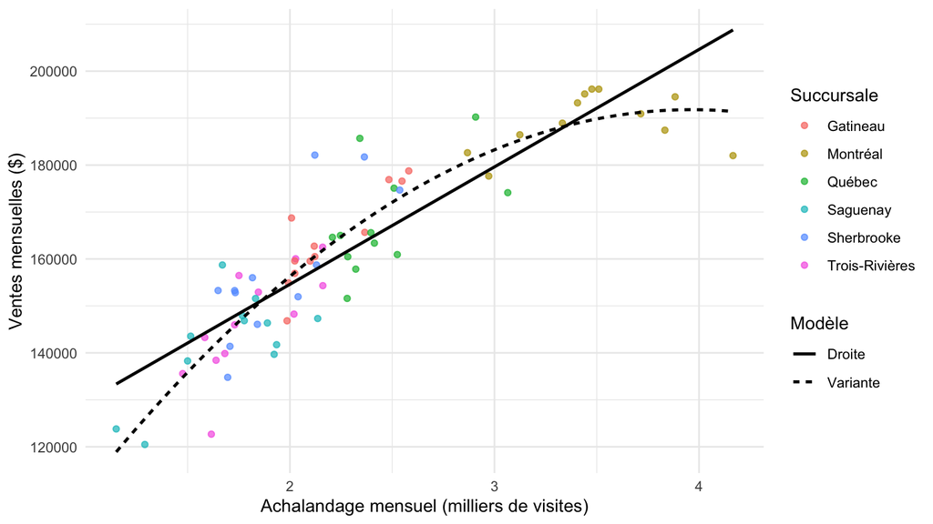

```r
plage <- range(saturation$achalandage_milliers)
grille <- tibble(achalandage_milliers = seq(plage[1], plage[2], length.out = 100))
courbes <- grille |>
  mutate(Droite = predict(modele_reference, newdata = grille),
         Variante = predict(modele_variante, newdata = grille)) |>
  pivot_longer(c(Droite, Variante), names_to = "modele", values_to = "ventes_estimees")

ggplot(saturation, aes(achalandage_milliers, ventes)) +
  geom_point(aes(colour = succursale), alpha = 0.7) +
  geom_line(data = courbes,
            aes(y = ventes_estimees, linetype = modele), linewidth = 0.9) +
  labs(x = "Achalandage mensuel (milliers de visites)", y = "Ventes mensuelles ($)",
       colour = "Succursale", linetype = "Modèle") +
  theme_minimal()
```

```r
# Deux niveaux choisis dans la plage pour illustrer la variation estimée.
scenarios <- tibble(achalandage_milliers = as.numeric(
  quantile(saturation$achalandage_milliers, probs = c(0.25, 0.75))))
scenarios <- scenarios |>
  mutate(ventes_estimees = predict(modele_variante, newdata = scenarios))
scenarios
```

```
# A tibble: 2 × 2
  achalandage_milliers ventes_estimees
                 <dbl>           <dbl>
1                 1.77         147650.
2                 2.51         172414.
```

```r
diff(scenarios$ventes_estimees)
```

```
       2
24763.78
```

Nommez les deux niveaux et les unités dans votre phrase. Cette différence est celle des moyennes estimées par le modèle à ces points; elle n’est ni une pente constante, ni un effet causal.

## Examiner les résidus

**AstuceOuvrir l’exemple de diagnostic**

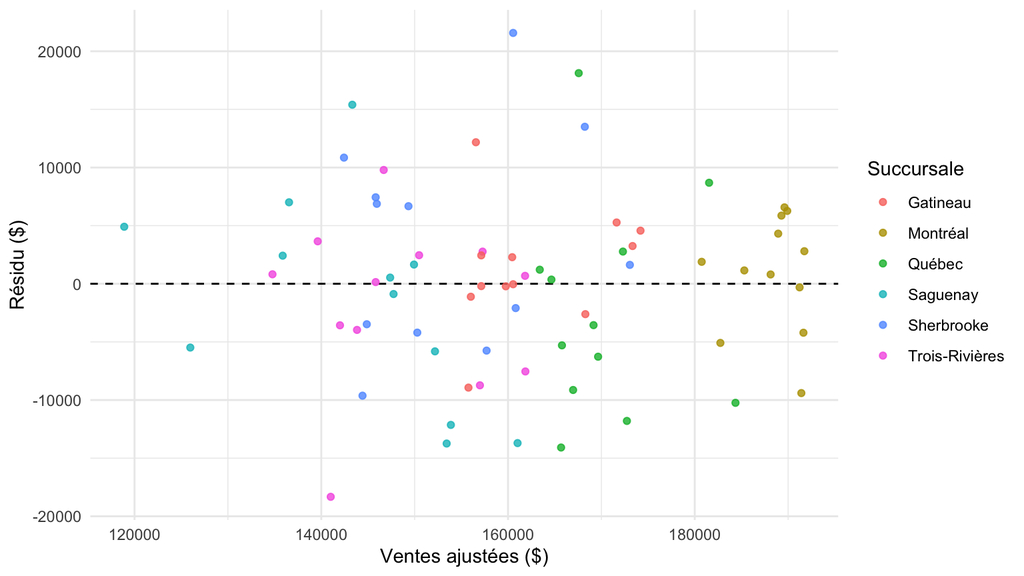

```r
# Cet exemple montre les résidus d'un modèle.
# Dans la mission, présentez les résidus de la droite et du modèle quadratique.
diagnostic <- saturation |>
  mutate(valeur_ajustee = fitted(modele_variante),
         residu = residuals(modele_variante))

ggplot(diagnostic, aes(valeur_ajustee, residu, colour = succursale)) +
  geom_hline(yintercept = 0, linetype = "dashed") +
  geom_point(alpha = 0.8) +
  labs(x = "Ventes ajustées ($)", y = "Résidu ($)", colour = "Succursale") +
  theme_minimal()
```

Décrivez ce que vous voyez effectivement : courbure, dispersion, groupes ou points à examiner. Ce seul graphique ne permet pas de vérifier l’indépendance entre mois ni de garantir la performance future.

## Revenir à votre analyse

La mission demande vos choix, vos résultats et votre conclusion. Consultez les repères pour vérifier une interprétation et les lectures pour la documentation officielle.

[IA Assistant IA Ouvrir le GPT du cours](https://chatgpt.com/g/g-6a0b2ec33d948191ad25b2f247b15de1-analyse-et-modelisation-des-donnees?ref=mini)